# PMA Data Explore

Matt Gunther

3/10/2022

```r
# load libraries and source functions
source(here::here("r/functions.R"))
setup_icfp()

# load pma longitudinal samples (wide format, female respondents only)
dat <- read_ipums_micro(
 ddi = here("data/pma_00114.xml"),
 data = here("data/pma_00114.dat.gz")
)
```

```
## Use of data from IPUMS PMA is subject to conditions including that users should
## cite the data appropriately. Use command `ipums_conditions()` for more details.
```

```r
# Setup
dat <- dat %>%
  mutate(
    POP = case_when(
      !is.na(GEOCD) ~ paste("DRC -", GEOCD %>% as_factor),
      !is.na(GEONG) ~ paste("Nigeria -", GEONG %>% as_factor),
      TRUE ~ COUNTRY %>% as_factor %>% as.character
    ),
    EAID = EAID_1,
    STRATA = if_else(!is.na(GEOCD), GEOCD %>% as.integer,
                     STRATA_1 %>% as.integer)
  ) %>%
  filter(
    RESULTFQ_1 == 1 & RESULTFQ_2 == 1,
    RESIDENT_1 %in% c(11, 22) & RESIDENT_2 %in% c(11, 22)
  )
```

# Reasons for Unmet Need

Senderowicz and Maloney [-@Senderowicz2022-ao] critique unmet need because it conflates access and demand:

> Demand-side unmet need represents women who are choosing not to use contraception, not because contraception is inaccessible, but because they do not see a need for it in their own lives.

Machiyama et al. [-@Machiyama2017-mp] propose a 5-part causal framework for unmet need.

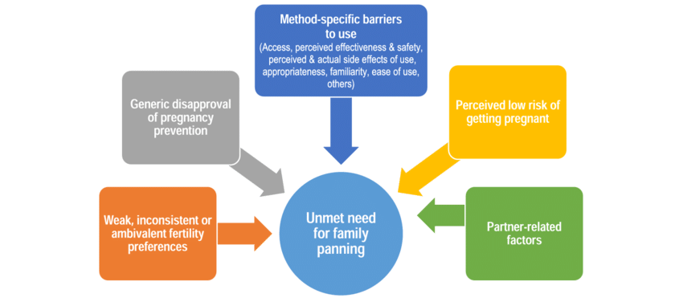

```r
knitr::include_graphics(here("images/causes.png"))
```

# PMA

PMA’s definition for unmet need *excludes* women who are infecund / menopausal, not sexually active, PPA following an intended birth, or used EC in the last 12 months. We may have non-use reasons for these women, but we’ll exclude them from our analysis.

```r
dat <- dat %>% mutate(EXCLUDE = UNMETYN_1 != 1)
```

PMA’s definition for unmet need may *include* women who are currently pregnant or open (ambivalent) to a pregnancy within the next two years. It may also include women who gave no reason (non-response). We cannot account for their non-use reasons.

```r
dat <- dat %>%
  mutate(
    NIU = if_any(starts_with("FPYNOT") & ends_with("1"), ~.x == 99),
    FPYNOTPREG = PREGNANT_1 == 1,
    FPYNOTUNSURE = FERTPREF_1 == 97 | PREFTIMECH_1 == 97,
    FPYNOTNR = NIU & !EXCLUDE & !FPYNOTPREG & !FPYNOTUNSURE
  )
```

Leigh S has proposed classifying reasons for unmet need into “supply” and “demand”. What if we propose another classification?

Long-term Demand: - Menopausal / Hysterectomy - Subfecund / Infecund - Up to God / fatalistic - Respondent opposed - Husband / partner opposed - Others opposed - Religious prohibition - Inconvenient to use - Interferes with body’s processes - Fear of side effects - Health concerns - Not married - Infrequent sex / Not having sex

Short-term Demand: - Not menstruated since last birth - Breastfeeding - Husband away for multiple days - *Currently pregnant*

Access: - Knows no method - Knows no source - Lack of access / too far - Costs too much - Preferred method not available - No method available

Other: - Other - Do not know - *No response* - *Unsure about future pregnancy*

```r
dat %>%
  select(starts_with("FPYNOT") & ends_with("1")) %>%
  ipums_var_info()
```

```
## # A tibble: 24 × 4
##    var_name        var_label                                    var_d…¹ val_la…²
##    <chr>           <chr>                                        <chr>   <list>
##  1 FPYNOTFAR_1     Reason not using FP: lack of access/too far  "For w… <tibble>
##  2 FPYNOTBODY_1    Reason not using FP: intereferes with body   "For w… <tibble>
##  3 FPYNOTBSTFD_1   Reason not using FP: breastfeeding           "For w… <tibble>
##  4 FPYNOTCOST_1    Reason not using FP: costs too much          "For w… <tibble>
##  5 FPYNOTKNO_1     Reason not using FP: knows no method         "For w… <tibble>
##  6 FPYNOTSRC_1     Reason not using FP: knows no source         "For w… <tibble>
##  7 FPYNOTDK_1      Reason not using FP: don't know              "For w… <tibble>
##  8 FPYNOTSIDEF_1   Reason not using FP: fear of side effects    "For w… <tibble>
##  9 FPYNOTSDHLTH_1  Reason not using FP: health concerns         "For w… <tibble>
## 10 FPYNOTHSBAWAY_1 Reason not using FP: husband away            "For w… <tibble>
## 11 FPYNOTOPPH_1    Reason not using FP: husband/partner opposed "For w… <tibble>
## 12 FPYNOTCONV_1    Reason not using FP: inconvenient to use     "For w… <tibble>
## 13 FPYNOTMENO_1    Reason not using FP: menopausal/hysterectomy "For w… <tibble>
## 14 FPYNOTAMEN_1    Reason not using FP: no menses since last b… "For w… <tibble>
## 15 FPYNOTAVAIL_1   Reason not using FP: no method available     "For w… <tibble>
## 16 FPYNOTNOSEX_1   Reason not using FP: not having sex          "For w… <tibble>
## 17 FPYNOTMAR_1     Reason not using FP: not married             "For w… <tibble>
## 18 FPYNOTOTH_1     Reason not using FP: other                   "For w… <tibble>
## 19 FPYNOTOPPO_1    Reason not using FP: others opposed          "For w… <tibble>
## 20 FPYNOTAVAILP_1  Reason not using FP: preferred method not a… "For w… <tibble>
## 21 FPYNOTRELIG_1   Reason not using FP: religious prohibition   "For w… <tibble>
## 22 FPYNOTOPPF_1    Reason not using FP: respondent opposed      "For w… <tibble>
## 23 FPYNOTINF_1     Reason not using FP: sub/infecund            "For w… <tibble>
## 24 FPYNOTFATE_1    Reason not using FP: up to god/fatalistic    "For w… <tibble>
## # … with abbreviated variable names ¹var_desc, ²val_labels
```

```r
output <- dat %>%
  transmute(
    POP,
    PANELWEIGHT, EAID, STRATA,
    EXCLUDE,
    UNMET = UNMETYN_2 == 1,
    LONG = if_any(
      c(
        FPYNOTMENO_1,
        FPYNOTINF_1,
        FPYNOTFATE_1,
        FPYNOTOPPF_1,
        FPYNOTOPPO_1,
        FPYNOTOPPH_1,
        FPYNOTRELIG_1,
        FPYNOTCONV_1,
        FPYNOTBODY_1,
        FPYNOTSIDEF_1,
        FPYNOTSDHLTH_1,
        FPYNOTMAR_1,
        FPYNOTNOSEX_1,
      ),
      ~.x == 1
    ),
    SHORT = if_any(
      c(
        FPYNOTAMEN_1,
        FPYNOTBSTFD_1,
        FPYNOTHSBAWAY_1,
        FPYNOTPREG,
      ),
      ~.x == 1
    ),
    ACCESS = if_any(
      c(
        FPYNOTKNO_1,
        FPYNOTSRC_1,
        FPYNOTFAR_1,
        FPYNOTCOST_1,
        FPYNOTAVAILP_1,
        FPYNOTAVAIL_1
      ),
      ~.x == 1
    ),
    OTHER = if_any(
      c(
        FPYNOTUNSURE,
        FPYNOTOTH_1,
        FPYNOTDK_1,
        FPYNOTNR,
      ),
      ~.x == 1
    )
  ) %>%
  mutate(across(where(is.logical) & !EXCLUDE, ~case_when(!EXCLUDE ~ .x)))
```

```r
glm(
  formula = UNMET ~ EXCLUDE + LONG + SHORT + ACCESS + OTHER +
    LONG*ACCESS + LONG*SHORT + SHORT*ACCESS,
  family = "binomial",
  data = output %>% filter(POP == "Burkina Faso")) %>%
  tidy(exp = TRUE) %>%
  mutate(sig = gtools::stars.pval(p.value))
```

```
## # A tibble: 9 × 6
##   term                 estimate std.error statistic    p.value sig
##   <chr>                   <dbl>     <dbl>     <dbl>      <dbl> <chr>
## 1 (Intercept)             0.238     0.353    -4.07   0.0000477 "***"
## 2 EXCLUDETRUE            NA        NA        NA     NA         ""
## 3 LONGTRUE                2.10      0.351     2.12   0.0342    "*"
## 4 SHORTTRUE               2.21      0.360     2.21   0.0274    "*"
## 5 ACCESSTRUE              3.68      0.547     2.38   0.0171    "*"
## 6 OTHERTRUE               1.79      0.318     1.83   0.0678    "."
## 7 LONGTRUE:ACCESSTRUE     0.320     0.738    -1.54   0.122     " "
## 8 LONGTRUE:SHORTTRUE      0.679     0.459    -0.842  0.400     " "
## 9 SHORTTRUE:ACCESSTRUE    0.763     1.10     -0.245  0.806     " "
```

```r
output %>%
  filter(POP == "Burkina Faso") %>%
  as_survey_design(weight = PANELWEIGHT, id = EAID, strata = STRATA) %>%
  svyglm(UNMET ~ EXCLUDE + LONG + SHORT + ACCESS + OTHER +
           LONG*ACCESS + LONG*SHORT + SHORT*ACCESS,
         family = "quasibinomial",
         design = .) %>%
  tidy() %>%
  mutate(sig = gtools::stars.pval(p.value))
```

```
## # A tibble: 8 × 6
##   term                 estimate std.error statistic   p.value sig
##   <chr>                   <dbl>     <dbl>     <dbl>     <dbl> <chr>
## 1 (Intercept)            -2.07      0.453    -4.57  0.0000101 "***"
## 2 LONGTRUE                1.45      0.427     3.40  0.000870  "***"
## 3 SHORTTRUE               1.76      0.469     3.75  0.000251  "***"
## 4 ACCESSTRUE              2.03      0.742     2.74  0.00684   "**"
## 5 OTHERTRUE               0.964     0.356     2.71  0.00756   "**"
## 6 LONGTRUE:ACCESSTRUE    -1.62      0.930    -1.75  0.0830    "."
## 7 LONGTRUE:SHORTTRUE     -1.36      0.584    -2.32  0.0216    "*"
## 8 SHORTTRUE:ACCESSTRUE   -0.539     2.03     -0.265 0.791     " "
```

```r
output %>%
  group_by(POP) %>%
  summarise(
    x = cur_data() %>%
      as_survey_design(weight = PANELWEIGHT, id = EAID, strata = STRATA) %>%
      svyglm(UNMET ~ EXCLUDE + LONG + SHORT + ACCESS + OTHER +
          LONG*ACCESS + LONG*SHORT + SHORT*ACCESS,
        family = "quasibinomial",
        design = .) %>%
      tidy() %>%
      mutate(sig = gtools::stars.pval(p.value)) %>%
      list()
  ) %>%
  unnest(x) %>%
  print(n = Inf)
```

```
## # A tibble: 46 × 7
##    POP                 term              estimate std.e…¹ statis…² p.value sig
##    <chr>               <chr>                <dbl>   <dbl>    <dbl>   <dbl> <chr>
##  1 Burkina Faso        (Intercept)       -2.07e+0   0.453 -4.57e+0 1.01e-5 "***"
##  2 Burkina Faso        LONGTRUE           1.45e+0   0.427  3.40e+0 8.70e-4 "***"
##  3 Burkina Faso        SHORTTRUE          1.76e+0   0.469  3.75e+0 2.51e-4 "***"
##  4 Burkina Faso        ACCESSTRUE         2.03e+0   0.742  2.74e+0 6.84e-3 "**"
##  5 Burkina Faso        OTHERTRUE          9.64e-1   0.356  2.71e+0 7.56e-3 "**"
##  6 Burkina Faso        LONGTRUE:ACCESST… -1.62e+0   0.930 -1.75e+0 8.30e-2 "."
##  7 Burkina Faso        LONGTRUE:SHORTTR… -1.36e+0   0.584 -2.32e+0 2.16e-2 "*"
##  8 Burkina Faso        SHORTTRUE:ACCESS… -5.39e-1   2.03  -2.65e-1 7.91e-1 " "
##  9 DRC - Kinshasa      (Intercept)        1.75e-1   0.854  2.05e-1 8.38e-1 " "
## 10 DRC - Kinshasa      LONGTRUE          -6.76e-1   0.929 -7.28e-1 4.70e-1 " "
## 11 DRC - Kinshasa      SHORTTRUE         -1.31e+0   0.864 -1.52e+0 1.35e-1 " "
## 12 DRC - Kinshasa      ACCESSTRUE         1.51e-1   1.67   9.04e-2 9.28e-1 " "
```

[output cut: 35 more lines]